# Rent

**Week 1 Analysis**

```r
# This gray area is called an "R-chunk".
# These library commands install some powerful functions for your use later on.
library(mosaic)
library(pander)
library(tidyverse)
library(DT)

# This read_csv command reads in the "Rent" data set into an object called "Rent"
Rent <- read_csv("../Data/rent.csv")

# To load this data set into your R-Console do the following:
#  1. From your top file menu select "Session -> Set Working Directory -> To Source File Location"
#  2. Press the green "play button" in the top right corner of this gray box (which is called an "R-chunk").
#  3. Then in your "Console" window run View(Rent)
```

## Background

Here is a data table showing the available approved housing apartment options at BYU-Idaho for single students.

```r
# Code to get you started.
# View(...) works great in the Console, but datatable(...) must be
# used instead within an R-chunk.
datatable(Rent, options=list(lengthMenu = c(3,10,30)), extensions="Responsive")
```

|  | Apartment Name | Address | Phone | Price Low | Price High | StatusFall25 | Housing Type | Residents | ParkingSpaces | Deposit | FloorPlanNumber | WebAddress | Latitude | Longitude | PublicDescription | CrowFlyMetersToMC | CrowFlyMetersToRicks |
| --- | --- | --- | --- | --- | --- | --- | --- | --- | --- | --- | --- | --- | --- | --- | --- | --- | --- |
| 1 | ABBY LANE MANOR | 437 4th W | 208-643-8731 | 1050 | 1450 | Full | Approved Women's Housing | 42 | 35 | 75 | 3 | www.abbylaneapartments.com | 43.81710724 | -111.7949519 | Abby Lane Manor is a women's complex offering spacious private and shared rooms that is just a ten minute walk from campus. Our girls enjoy amenities such as free laundry, personal vanities in each be… | 1013.452507 | 1122.738924 |
| 2 | ABRI APARTMENTS - MEN | 220 E 1st S Rexburg, ID 83440 | (208) 417-7223 | 1800 | 1850 | Full | Approved Men's Housing | 132 | 204 | 150 | 3 | www.liveabri.com | 43.82340456 | -111.7774263 | We offer two beautiful and unique floor plans! Our Deluxe is all one floor and our Townhome is two floors. Upscale, modern finishes, state-of-the-art fitness center, fully equipped clubhouse, study ro… | 685.7194219 | 998.1143226 |
| 3 | ABRI APARTMENTS - WOMEN | 220 E 1st S | 208-417-7223 | 1800 | 1850 | Waiting List | Approved Women's Housing | 144 | 204 | 150 | 3 | liveabri.com | 43.82340456 | -111.7774263 | Deluxe &amp; Townhome Floorplans! Offering early bird special of $100 off! Upscale, modern finishes, state-of-the-art fitness center, fully equipped clubhouse, study rooms, courtyard with firepit &amp… | 685.7194219 | 998.1143226 |
| 4 | ALLDREDGE HOUSE | 243 S 1st E Rexburg, ID 83440 | 208-794-0652 | 1095 | 1795 |  | Approved Men's Housing | 8 | 8 | 150 | 3 |  | 43.82074947 | -111.7806074 | Hurry quick! Come make ALLDREDGE HOUSE your home away from home! Located directly across the street from the Clarke Building and only a few blocks away from down town. Great Ward with the guys right n… | 297.9642846 | 654.8069923 |
| 5 | ALLEN'S SUNRISE VILLAGE - MEN | 48 W 2nd S Rexburg, ID 83440 | 208-356-3995 | 1145 | 1250 | Waiting List | Approved Men's Housing | 138 | 133 | 150 | 6 | www.sunrisevillageapts.com | 43.82275434 | -111.7857894 | Sale on multi-semester contracts happening now. Save up to $175 + FREE Laundry! We are well-known for our friendliness, two refrigerators, low prices, great location, our free laundry, reliable OPTIX … | 547.9407736 | 945.3011818 |
| 6 | ALLEN'S SUNRISE VILLAGE - WOMEN | 48 W 3rd S | 208-356-3995 | 1250 | 1295 | Waiting List | Approved Women's Housing | 144 | 133 | 150 | 3 | www.sunrisevillageapts.com | 43.82275434 | -111.7857894 | Sale on multi-semester contracts happening now. Save up to $175 + FREE Laundry! We are well-known for our friendliness, two refridgerators, low prices, great location, our free laundry, reliable OPTIX… | 547.9407736 | 945.3011818 |
| 7 | ALPINE CHALET | 460 S 2nd W Rexburg, ID 83440-2333 | (208) 356-9282 | 1049 | 1199 | Waiting List | Approved Men's Housing | 162 | 111 | 150 | 6 | www.rexburghousing.com/alpine-chalet | 43.81603117 | -111.790199 | Alpine Chalet is a great place to live! It is close to campus and surrounded by many BYUI housing complexes. It has an amazing pool, hot tub, and weight room. Not to mention, we added 2nd fridges and … | 675.4892138 | 724.1309331 |
| 8 | AMERICAN AVENUE - MEN | 151 S 1st E Rexburg, ID 83440-1900 | 208-356-5097 | 1225 | 1695 |  | Approved Men's Housing | 86 | 110 | 150 | 7 | www.myamericanavenue.com | 43.8227079 | -111.779674 | At American Avenue we have several apartment layouts for you to make home. We are currently under renovation and things are amazing! Our apartment homes have shared room or private room options next t… | 525.5349955 | 880.0143182 |
| 9 | AMERICAN AVENUE-WOMEN | 151 E 4th E | 208-350-5097 | 1250 | 1250 | Full | Approved Women's Housing | 138 | 110 | 150 | 2 | www.myamericanavenue.com | 43.8227079 | -111.779674 | At American Avenue we have several apartment layouts for you to make home. We are currently under renovation and things are amazing! Our apartment homes have shared room or private room options next t… | 525.5349955 | 880.0143182 |
| 10 | ARCADIA APARTMENTS | 138 W 4th S Rexburg, ID 83440-2487 | 208-881-2935 | 1095 | 1095 | Full | Approved Men's Housing | 41 | 30 | 100 | 6 | www.arcadiarexburg.com | 43.81813297 | -111.7880264 | Arcadia Apartments is located just across from the BYU-Idaho Center, literally steps from campus. Arcadia is priced at just $400. Arcadia offers clean, comfortable apartments with a very social atmosp… | 446.7110607 | 648.0849819 |

[output cut: 97 more lines]

## Graphic

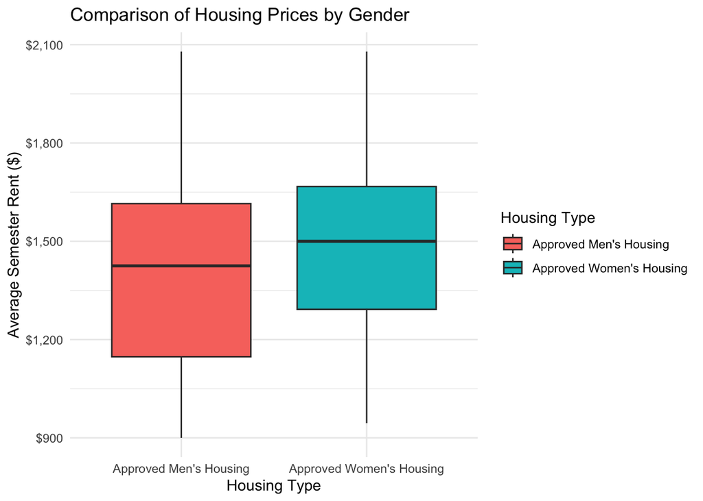

```r
# Use this R-chunk to...
# ...Create an interesting graphic using the Rent data set.

Rent_Filtered <- Rent %>%
  mutate(Price_Avg = (`Price Low` + `Price High` ) / 2 ) %>%
  filter(`Housing Type` %in% c("Approved Men's Housing", "Approved Women's Housing"))

ggplot(Rent_Filtered, aes(x = `Housing Type`, y = Price_Avg, fill = `Housing Type`)) +
  geom_boxplot() +
  labs(
    title = "Comparison of Housing Prices by Gender",
    x = "Housing Type",
    y = "Average Semester Rent ($)",
    fill = "Housing Type"
  ) +
  theme_minimal()+
  scale_y_continuous(labels = scales::dollar)
```

The box plot reveals a distinct trend where approved women’s housing is generally more expensive per semester than approved men’s housing. This is evidenced by the higher median price for women’s apartments and the upward shift of their entire central 50% price range. Although the absolute cheapest and most expensive options are similar for both, the data indicates that the typical student seeking women’s housing should expect to pay more.

```r
# Use this R-chunk to...
# ...compute and display a meaningful table of numerical summaries supporting your above graphic.
Rent_Filtered %>%
  group_by(`Housing Type`) %>%
  summarise(
    Count = n(),
    Mean_Price = mean(Price_Avg, na.rm = TRUE),
    Median_Price = median(Price_Avg, na.rm = TRUE)
  ) %>%
  pander()
```

| Housing Type | Count | Mean_Price | Median_Price |
| --- | --- | --- | --- |
| Approved Men’s Housing | 55 | 1405 | 1425 |
| Approved Women’s Housing | 52 | 1473 | 1500 |

This table of numerical summaries provides quantitative validation for the trends observed in the box plot. The data, compiled from 55 men’s and 52 women’s housing complexes, shows a clear price difference between the two categories. Specifically, the mean rent for women’s housing at $1,473 and the median rent at $1,500 are substantially higher than the corresponding figures for men’s housing, which are $1,405 and $1,425, respectively.

## Conclusion

In conclusion, this analysis clearly answers the main question: women’s approved housing is more expensive than men’s. Both the box plot graph and the summary table support this, showing that the average and middle prices are higher for women. Therefore, a student looking for women’s housing in the area should plan to budget more for rent each semester.